# Useing our new function (timestep_deterministic_SIS)

Edie Bishop

13th of November 2019

# Introduction

In this script we call on a new function (timestep_deterministic_SIS), which takes a value for disease transmission rate, a value for recovery rate, and a value for timestep, and returns a dataframe with three columns (usceptibles, infecteds, and time). The model that this function produces can be represented mathamatically by the following equation:
$$S(t + 1) = S(t) - \beta * S(t) * I(t) / N + \sigma * I(t)$$
$$I(t + 1) = I(t) + \beta * S(t) * I(t) / N - \sigma * I(t)$$
*Where S = susceptible animals, I = infected animals, t = time, $\beta$ = transmission rate & $\sigma$* *= recovery rate*

We will test our new function using two defined timesteps. Since transmission rate of *Escherichia coli* infection in cattle is usually represented as rate per week, we will specify timesteps so that we can model the population with daily timesteps and with eight-weekly timesteps.

We will then do the same thing, but using our previously created simpler function (step_deterministic_SIS), in which we cannot define a timestep, and need to specify the timesteps outside of the function.

### Source our functions

We need to source both our new function (timestep_deterministic_SIS), and our previous function (step_deterministic_SIS) as well as our plot_populations function.

```r
source("0301_plot_helper.R")
source("0303_timestep_SIS.R")
source("0301_step_SIS.R")
```

### Define parameters

To start with we define the population size and the transmission and recovery rates, in this case for E. coli infection in a herd of cattle.

```r
num.cattle <- 100
initial.infected <- 2
initial.susceptible <- num.cattle - initial.infected

ecoli.transmission <- 2/3
ecoli.recovery <- 1/3
```

Then we define the start time and the end time for our study, and the timesteps that we wish our model to run over.

```r
start.time <- 0
end.time <- 100
timestep.a <- 1/7
timestep.b <- 8
```

## Using step_deterministic_SIS

```r
herd.df.a <- data.frame(SUSCEPTIBLES = initial.susceptible,
                        INFECTED = initial.infected)
herd.df.b <- data.frame(SUSCEPTIBLES = initial.susceptible,
                        INFECTED = initial.infected)
```

### Run the function

Now we loop through the time itself (starting at the second time step). The for() command creates the loop, and then we call our function, step_deterministic_SIS(), which creates a new value for susceptiple and infected cattle at each time step. Define timesteps, which in this case will use the value timestep.a to specify what timesteps our model will run over

```r
timesteps.a <- seq(from = start.time + timestep.a, to = end.time, by = timestep.a)

for(new.time in timesteps.a) {
  ## Calculate the changes to the herd using or steo_deterministic_SIS() function
  updated.population <- step_deterministic_SIS(latest=tail(herd.df.a, 1),
                                               transmission.rate = ecoli.transmission * timestep.a,
                                               recovery.rate = ecoli.recovery * timestep.a)
  ## Then define the herd.df dataframe, which is the herd.df dataframe with the updated.population
  ## dataframe appended to the end of it.
  herd.df.a <- rbind(herd.df.a, updated.population)
}
```

We need to add another column (time) to our population.df dataframe, so that we can make a plot of population againsts time. We do this by using c() to add start.time and timesteps to the dataframe in a newly defined column below:

```r
herd.df.a$time <- c(start.time, timesteps.a)
```

We now do the same thing again, but using timestep.b to define the timesteps we want the model to run over.

```r
timesteps.b <- seq(from = start.time + timestep.b, to = end.time, by = timestep.b)

for(new.time in timesteps.b) {
  updated.population <- step_deterministic_SIS(latest=tail(herd.df.b, 1),
                                               transmission.rate = ecoli.transmission * timestep.b,
                                               recovery.rate = ecoli.recovery * timestep.b)
  herd.df.b <- rbind(herd.df.b, updated.population)
}
herd.df.b$time <- c(start.time, timesteps.b)
```

## Plot the results

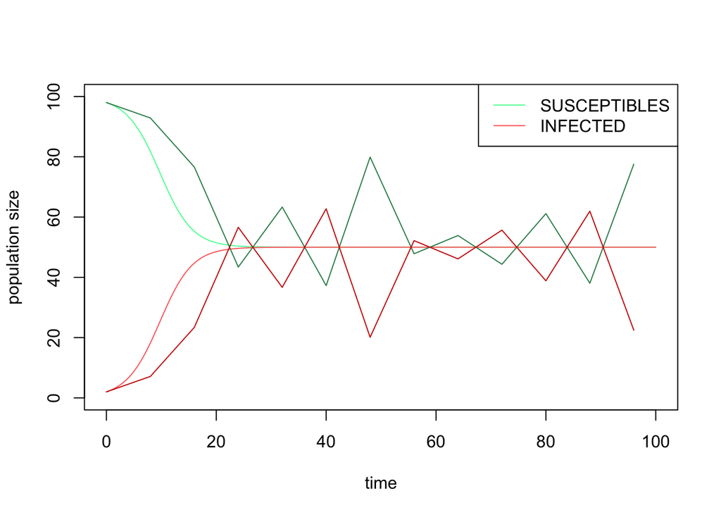

```r
plot_populations(herd.df.a, col = c("seagreen1", "indianred1"))
plot_populations(herd.df.b, new.graph = FALSE, col = c("seagreen", "red3"))
```

## Using timestep_deterministic_SIS

We will now use our more complex function, timestep_deterministic_SIS, which accepts four arguments: latest, timestep, transmission.rate and recovery.rate. We need to define our new dataframes, this time contianing three columns: number of susceptible cattle, number of infected cattle and time. We will use the same previously defined transmission and recovery rates for E. coli.

```r
herd.df.1 <- data.frame(SUSCEPTIBLES = initial.susceptible,
                        INFECTED = initial.infected,
                        time = start.time)
herd.df.2 <- data.frame(SUSCEPTIBLES = initial.susceptible,
                        INFECTED = initial.infected,
                        time = start.time)
```

### Run the function

Now we can run our new timestep_deterministic_SIS. This function can update time, along with the number of infected and susceptible individuals. Now we don’t need to make the vector of timesteps in advance, we can use a while() loop to decide when we’re finished.

```r
# we define a new dataframe which will be passed through the function
updated.population <- herd.df.1
# Rather than specifying timesteps, we can now use a while() loop to specify that we wish to continue running
# the function until we reach the end time.
while(updated.population$time < end.time)
{updated.population <-
  # our new function accepts four arguments, which we define below
  timestep_deterministic_SIS(latest = tail(herd.df.1, 1),
                             timestep = timestep.a,
                             transmission.rate = ecoli.transmission,
                             recovery.rate = ecoli.recovery)
# we then update the herd.1 dataframe by adding the updated population dataframe, which has been passed
# through the function, to it.
herd.df.1 <- rbind(herd.df.1, updated.population)
}
```

```r
# We will now do the same again, this time using timestep.b
updated.population <- herd.df.2
while(updated.population$time < end.time)
{updated.population <-
  timestep_deterministic_SIS(latest = tail(herd.df.2, 1),
                             timestep = timestep.b,
                             transmission.rate = ecoli.transmission,
                             recovery.rate = ecoli.recovery)
herd.df.2 <- rbind(herd.df.2, updated.population)
}
```

### Plot the results

We can now plot the results produced by the timestep_deterministic_SIS function, and see that they are the same as those produced above.

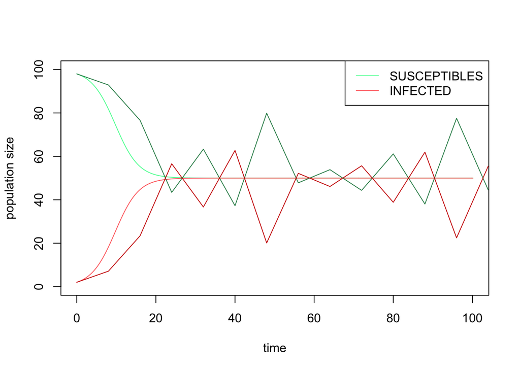

```r
plot_populations(herd.df.1, col = c("seagreen1", "indianred1"))
plot_populations(herd.df.2, new.graph = FALSE, col = c("seagreen", "red3"))
```

## Conclusion

The advantage of our new model is that we no longer need to to define a variable called “timesteps” prior to running the model. We can now just decide what timestep we want to simulate the model with, define that variable, and pass it to the function. This will decrease the risk of making errors involved with altering our transmission and recovery rates outside the function, as we know that the function can do this itself and do it correctly.